# Práctica Análisis Estadístico

Alicia Aguirre

## Ejercicio 1.1

```r
list.of.packages <- c("ggplot2", "dplyr")
new.packages <- list.of.packages[!(list.of.packages %in% installed.packages()[,"Package"])]
if (length(new.packages)) install.packages(new.packages)
require(ggplot2)
require(dplyr)
#Cagramos los datos
load("/home/usuario/Desktop/Analisis estadistico/Practica/trasplantes.rda")
trasplantes
```

```
##      id acceptyear age survived survtime prior transplant wait
## 1    15         68  53     dead        1    no    control   NA
## 2    43         70  43     dead        2    no    control   NA
## 3    61         71  52     dead        2    no    control   NA
## 4    75         72  52     dead        2    no    control   NA
## 5     6         68  54     dead        3    no    control   NA
## 6    42         70  36     dead        3    no    control   NA
## 7    54         71  47     dead        3    no    control   NA
## 8    38         70  41     dead        5    no  treatment    5
## 9    85         73  47     dead        5    no    control   NA
## 10    2         68  51     dead        6    no    control   NA
## 11  103         67  39     dead        6    no    control   NA
## 12   12         68  53     dead        8    no    control   NA
## 13   48         71  56     dead        9    no    control   NA
## 14  102         74  40    alive       11    no    control   NA
```

[output cut: 89 more lines]

```r
prior <- trasplantes$prior
levels(prior)
```

```
## [1] "no"  "yes"
```

```r
levels(prior)[1] <- "0"
levels(prior)[2] <- "1"
prior <- as.numeric(prior)-1
prior
```

```
##   [1] 0 0 0 0 0 0 0 0 0 0 0 0 0 0 0 0 0 0 0 0 0 0 0 0 0 0 0 0 0 0 1 0 0 0 0
##  [36] 0 0 0 0 0 0 0 0 0 0 0 0 0 0 0 0 0 0 0 0 0 0 0 0 0 1 0 1 0 0 0 0 0 0 0
##  [71] 0 0 0 0 1 0 0 0 0 1 0 1 1 0 0 0 0 0 0 0 0 0 1 1 0 1 1 0 0 1 0 0 0
```

```r
rep_sample_n <- function(tbl, size, replace = FALSE, reps=1)
{
    n <- nrow(tbl)
    i <- unlist(replicate(reps, sample.int(n, size, replace = replace), simplify = FALSE))

    rep_tbl <- cbind(replicate = rep(1:reps,rep(size,reps)), tbl[i, , drop = FALSE])

    dplyr::group_by(rep_tbl, replicate)
}
```

```r
# Generamos una muestra a partir de la población
set.seed(12345)
muestra <- sample(prior, replace = TRUE, size = 10)

muestra1<- tibble(muestra)
muestra1
```

```
## # A tibble: 10 x 1
##    muestra
##      <dbl>
##  1    1.00
##  2    0
##  3    0
##  4    0
##  5    0
##  6    0
##  7    0
##  8    0
##  9    1.00
## 10    0
```

```r
# Generamos 1000 remuestreos de la muestra con n=10
muestra_10 <- muestra1 %>%
  rep_sample_n(size = 10, replace = TRUE, reps = 1000)

# Generamos 1000 remuestreos de la muestra con n=3
muestra_3 <- muestra1 %>%
  rep_sample_n(size = 3, replace = TRUE, reps = 1000)

# Generamos 1000 remuestreos de la muestra con n=150
muestra_150 <- muestra1 %>%
  rep_sample_n(size = 150, replace = TRUE, reps = 1000)

# Calculamos p para cada encuesta
props_10 <- muestra_10 %>%
  summarize(prop_yes = mean(muestra))

props_3 <- muestra_3 %>%
  summarize(prop_yes = mean(muestra))

props_150 <- muestra_150 %>%
  summarize(prop_yes = mean(muestra))

# Vemos variabilidad de p
props_10 %>% summarize(sd(prop_yes))
```

```
## # A tibble: 1 x 1
##   `sd(prop_yes)`
##            <dbl>
## 1          0.128
```

```r
props_3 %>% summarize(sd(prop_yes))
```

```
## # A tibble: 1 x 1
##   `sd(prop_yes)`
##            <dbl>
## 1          0.236
```

```r
props_150 %>% summarize(sd(prop_yes))
```

```
## # A tibble: 1 x 1
##   `sd(prop_yes)`
##            <dbl>
## 1         0.0338
```

```r
# Calculamos la propocion de haber sido sometido a cirugía con aterioridad
props_10 <- muestra_10 %>%
  summarize(prop_yes = mean(muestra))
props_10
```

```
## # A tibble: 1,000 x 2
##    replicate prop_yes
##        <int>    <dbl>
##  1         1    0.200
##  2         2    0
##  3         3    0.200
##  4         4    0.300
##  5         5    0.200
##  6         6    0
##  7         7    0.100
##  8         8    0.600
##  9         9    0.300
## 10        10    0.100
## # ... with 990 more rows
```

```r
# Proporción de pacientes en 2 desviaciones típicas
props_10 %>%
  mutate(lower = 0.1165 - 2 * sd(prop_yes),
         upper = 0.1165 + 2 * sd(prop_yes),
         in_CI = prop_yes > lower & prop_yes < upper) %>%
  summarize(mean(in_CI))
```

```
## # A tibble: 1 x 1
##   `mean(in_CI)`
##           <dbl>
## 1         0.877
```

```r
# Calculamos p
p <- mean(muestra)

# Realizamos Bootstrap para encontrar las desviación típica de p
muestra_10 <- muestra1 %>%
  rep_sample_n(10, replace = TRUE, reps = 1000) %>%
  summarize(prop_yes = mean(muestra))

# Creamos un intervalo de valores posibles
muestra_10 %>%
  summarize(lower = p - 2 * sd(prop_yes),
            upper = p + 2 * sd(prop_yes))
```

```
## # A tibble: 1 x 2
##     lower upper
##     <dbl> <dbl>
## 1 -0.0520 0.452
```

```r
# Encontrar los cuantiles 0.025 y 0.975
muestra_10 %>%
  summarize(q025_prop = quantile(prop_yes, p = .025),
            q975_prop = quantile(prop_yes, p = .975))
```

```
## # A tibble: 1 x 2
##   q025_prop q975_prop
##       <dbl>     <dbl>
## 1         0     0.500
```

Conclusión: Podemos decir que la proporción de candidatos a trasplante de corazón que han sido sometidos a cirugía anteriormente está entre 0 y 0.50 con un nivel de confianza del 95%.

## Ejercicio 1.2

En primer lugar definimos las hipótesis que van a ser consideradas en el experimento:

Ho: treatment y survived son independientes

Ha: treatment y suvived no son independientes

```r
set.seed(1234)
##1.1
# Crear una tabla que resuma los datos

test <- trasplantes %>%
  select(survived, transplant)

muestra_test <- test[sample(nrow(test), 30),]

muestra_test
```

```
##     survived transplant
## 12      dead    control
## 64      dead  treatment
## 62     alive  treatment
## 63      dead  treatment
## 86     alive  treatment
## 100    alive  treatment
## 1       dead    control
## 23      dead  treatment
## 102    alive  treatment
## 49      dead  treatment
## 65      dead  treatment
## 51      dead    control
## 26      dead    control
## 84     alive  treatment
```

[output cut: 16 more lines]

```r
# Encontrar la proporción de vivos para trasplante o control
muestra_test %>%
  group_by(transplant) %>%
  summarize(survived_prop  = mean(survived == "alive"))
```

```
## # A tibble: 2 x 2
##   transplant survived_prop
##   <fct>              <dbl>
## 1 control            0.111
## 2 treatment          0.429
```

```r
# Muestreamos el data frame completo 5 veces
muestra_test %>%
  rep_sample_n(size = nrow(muestra_test), reps = 1000)
```

```
## # A tibble: 30,000 x 3
## # Groups:   replicate [1,000]
##    replicate survived transplant
##  *     <int> <fct>    <fct>
##  1         1 alive    treatment
##  2         1 dead     treatment
##  3         1 alive    treatment
##  4         1 alive    treatment
##  5         1 alive    treatment
##  6         1 dead     treatment
##  7         1 dead     treatment
##  8         1 alive    treatment
##  9         1 dead     treatment
## 10         1 alive    control
## # ... with 29,990 more rows
```

```r
# Mezclamos la variable survived dentro de cada replica
muestra_test %>%
  rep_sample_n(size = nrow(muestra_test), reps = 1000)  %>%
  mutate(surv_perm = sample(survived))
```

```
## # A tibble: 30,000 x 4
## # Groups:   replicate [1,000]
##    replicate survived transplant surv_perm
##        <int> <fct>    <fct>      <fct>
##  1         1 dead     control    dead
##  2         1 alive    treatment  alive
##  3         1 dead     treatment  dead
##  4         1 alive    treatment  dead
##  5         1 dead     treatment  dead
##  6         1 dead     treatment  dead
##  7         1 alive    treatment  dead
##  8         1 dead     control    dead
##  9         1 dead     treatment  dead
## 10         1 dead     control    dead
## # ... with 29,990 more rows
```

```r
# Encontramos la proporcón de supervivienes por cada replica y tratamiento
muestra_test %>%
  rep_sample_n(size = nrow(muestra_test), reps = 1000)  %>%
  mutate(surv_perm = sample(survived)) %>%
  group_by(replicate, transplant) %>%
  summarize(prop_surv_perm = mean(surv_perm == "alive"),
            prop_surv = mean(survived== "alive"))
```

```
## # A tibble: 2,000 x 4
## # Groups:   replicate [?]
##    replicate transplant prop_surv_perm prop_surv
##        <int> <fct>               <dbl>     <dbl>
##  1         1 control             0.444     0.111
##  2         1 treatment           0.286     0.429
##  3         2 control             0.444     0.111
##  4         2 treatment           0.286     0.429
##  5         3 control             0.333     0.111
##  6         3 treatment           0.333     0.429
##  7         4 control             0.444     0.111
##  8         4 treatment           0.286     0.429
##  9         5 control             0.111     0.111
## 10         5 treatment           0.429     0.429
## # ... with 1,990 more rows
```

```r
# Diferencias de proporciones de vivos
diferencias <- muestra_test %>%
  rep_sample_n(size = nrow(muestra_test), reps = 1000)  %>%
  mutate(surv_perm = sample(survived)) %>%
  group_by(replicate, transplant) %>%
  summarize(prop_surv_perm = mean(surv_perm == "alive"),
            prop_surv = mean(survived== "alive"))  %>%
  summarize(diff_perm = diff(prop_surv_perm),
            diff_orig = diff(prop_surv))
diferencias
```

```
## # A tibble: 1,000 x 3
##    replicate diff_perm diff_orig
##        <int>     <dbl>     <dbl>
##  1         1     0         0.317
##  2         2     0         0.317
##  3         3     0.159     0.317
##  4         4     0.159     0.317
##  5         5     0         0.317
##  6         6    -0.159     0.317
##  7         7     0.159     0.317
##  8         8    -0.159     0.317
##  9         9     0         0.317
## 10        10     0.159     0.317
## # ... with 990 more rows
```

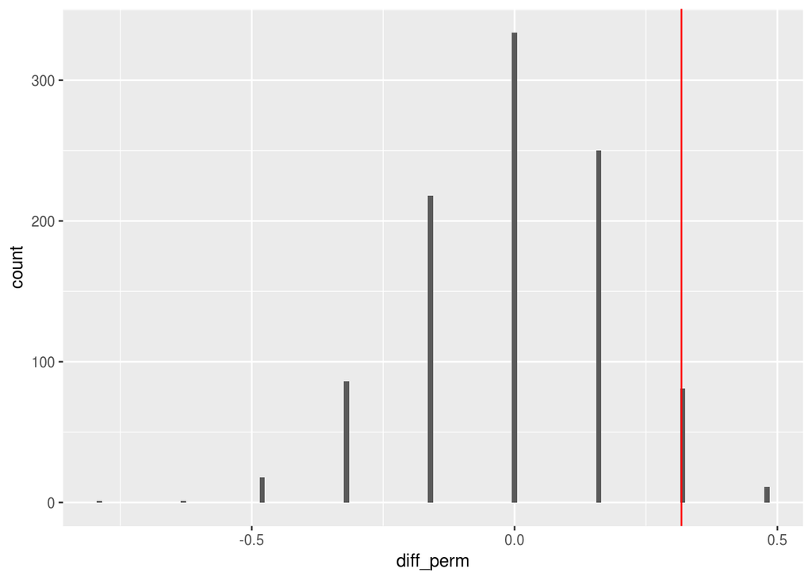

```r
# Histograma de las diferencias permutadas
ggplot(diferencias, aes(x = diff_perm)) +
  geom_histogram(binwidth = 0.01) +
  geom_vline(aes(xintercept = diff_orig), col = "red")
```

```r
# Encontrar los cuantiles 0.90, 0.95 y 0.99 de las diferencias permutadas
diferencias %>%
  summarize(q.90 = quantile(diff_perm, p = 0.90),
            q.95 = quantile(diff_perm, p = 0.95),
            q.99 = quantile(diff_perm, p = 0.99))
```

```
## # A tibble: 1 x 3
##    q.90  q.95  q.99
##   <dbl> <dbl> <dbl>
## 1 0.159 0.317 0.476
```

```r
# Encontrar los cuantiles 0.10, 0.05 y 0.01 de las diferencias permutadas
diferencias %>%
  summarize(q.01 = quantile(diff_perm, p = 0.01),
            q.05 = quantile(diff_perm, p = 0.05),
            q.10 = quantile(diff_perm, p = 0.10))
```

```
## # A tibble: 1 x 3
##     q.01   q.05   q.10
##    <dbl>  <dbl>  <dbl>
## 1 -0.476 -0.317 -0.317
```

## Ejercicio 2.1

Resumen de los datos:

```r
Tratamiento <- c("Pioglitazone", "Rosiglitazone", "Total")
Problemas_SI <- c(5386, 2593, 7979)
Problemas_NO <- c(154592, 65000, 219592)
Total <- c(159978, 67593, 227571)
datos <- data.frame(Tratamiento, Problemas_SI, Problemas_NO, Total)
datos
```

```
##     Tratamiento Problemas_SI Problemas_NO  Total
## 1  Pioglitazone         5386       154592 159978
## 2 Rosiglitazone         2593        65000  67593
## 3         Total         7979       219592 227571
```

1.Como hay más pacientes con pioglitazone que tienen problemas cardiovasculares (5,386 frente a 2,593), podemos concluir que el ratio de problemas cardiovasculares de aquellos pacientes tratados con pioglitazone es mayor.

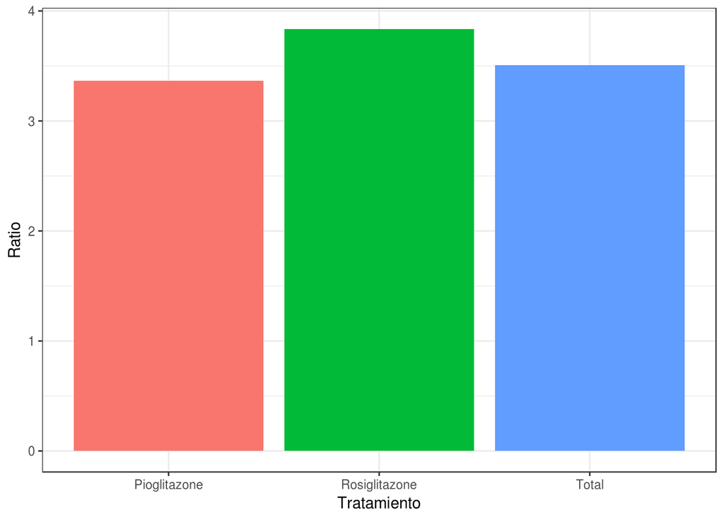

```r
datos %>%
  group_by(Tratamiento) %>%
  summarize(Ratio =(Problemas_SI/Total)*100) %>%
  ggplot(aes(Tratamiento,Ratio,fill = Tratamiento)) +
  geom_bar(stat = "identity", position = "dodge") +
  guides(fill = "none") +
  theme_bw()
```

FALSO. Podemos concluir que a pesar de que hay más pacientes con pioglitazone que tienen problemas cardiovasculares, el ratio de problemas cardiovasculares con Rosiglitazone es mayor.

2.Los datos sugieren que los pacientes diabéticos que están tomando rosiglitazone son más propensos a sufrir problemas cardiovasculares ya que el ratio de incidencia es de 3.8 % (2; 593/67; 593 = 0.038) en pacientes con este tratamiento, mientras que es de 3.4 % (5; 386/159; 978 = 0.034) para pacientes con tratamiento de pioglitazone.

```r
datos %>%
  group_by(Tratamiento) %>%
  summarize(Ratio =(Problemas_SI/Total)*100)
```

```
## # A tibble: 3 x 2
##   Tratamiento   Ratio
##   <fct>         <dbl>
## 1 Pioglitazone   3.37
## 2 Rosiglitazone  3.84
## 3 Total          3.51
```

VERDADERO.

3.Que el ratio de incidencia para el grupo con tratamiento rosiglitazone sea mayor demuestra que el rosiglitazone causa serios problemas cardiovasculares.

```r
Tot <- datos[2,4]

datos %>%
  select(Tratamiento, Problemas_SI, Problemas_NO) %>%
  filter(Tratamiento=="Rosiglitazone") %>%
  summarize(Ratio1 =(Problemas_SI/Tot)*100,
            Ratio2 =(Problemas_NO/Tot)*100)
```

```
##     Ratio1  Ratio2
## 1 3.836196 96.1638
```

FALSO. Que el ratio de incidencia para el grupo con tratamiento rosiglitazone sea mayor demuestra que es mayor el riesgo de sufrir problemas cardiovasculares graves con respecto al tratamiento pioglitazone, a simple vista (tendremos que analizar si existe diferencia significativa entre ambos ratios). Por otro lado, lo único que puede decirse con respecto a los ratios es que ambos tratamientos causan problemas cardiovasculares, pero a una pequeña parte de los pacientes como puede verse en la comparación de Ratio1 y Ratio2 para el caso de rosiglitazone.

4.Basándonos en la información dada hasta aquí, no podemos afirmar si la diferencia entre los ratios de incidencia se debe a la relación entre ambas variables o al azar.

VERDADERO. Sería necesario realizar un test de hipóteis.

## Ejercicio 2.2

Planteamiento de la hipótesis nula y alternativa:

hnula: Tratamiento y Problemas Cardiovasculares son independientes

halternativa: Tratamiento y Problemas Cardiovasculares no son independientes